# K-prototype

## 資料前處理

```r
library(dummies)
library(tidyverse)
library(readr)
library(clustMixType)
getwd()
```

```
## [1] "C:/Users/user/Desktop/tmp/R/SAS_R_commercial/HW3"
```

```r
setwd(".\\data")
data1 <- read.csv("airline_survey.csv")
sta <- function(x){
  (x - min(x)) / (max(x) - min(x))
}
data1 <- data1[c(1:10000),]
data1 <- data1[,-c(1,2)]

data2 <- data1 %>%
  mutate(
    Age = sta(Age),
    Flight.Distance = sta(Flight.Distance),
    Departure.Delay.in.Minutes = sta(Departure.Delay.in.Minutes),
    Arrival.Delay.in.Minutes = sta(Departure.Delay.in.Minutes)
  )

dummies=dummy.data.frame(data2)

for(i in 12:25){
  dummies[,i] = as.factor(dummies[,i])
}
dummies1 = dummies[,-c(2,4,7,10,23)]

for(i in c(1,2,4,5,6,8:20,23,24)){
  dummies1[,i] = as.factor(dummies1[,i])
}
```

## 選定使用的算法(k-proto)

### 1. 決定最佳群數，參考elbow method後選擇應選群(應選8群，但考量到分類太過細碎複雜，因此只選用7群)

```r
Total_within_sum_of_sqare = c()
Number_of_cluster_k = c(1:20)
for(i in c(1:20)){
  sse = kproto(x = dummies1,k=i ,iter.max = 100, nstart = 1)
  Total_within_sum_of_sqare = append(Total_within_sum_of_sqare, sse$tot.withinss)
}

library(ggplot2)
p_df = data.frame(
  Total_within_sum_of_sqare = Total_within_sum_of_sqare,
  Number_of_cluster_k = c(1:20)
)
```

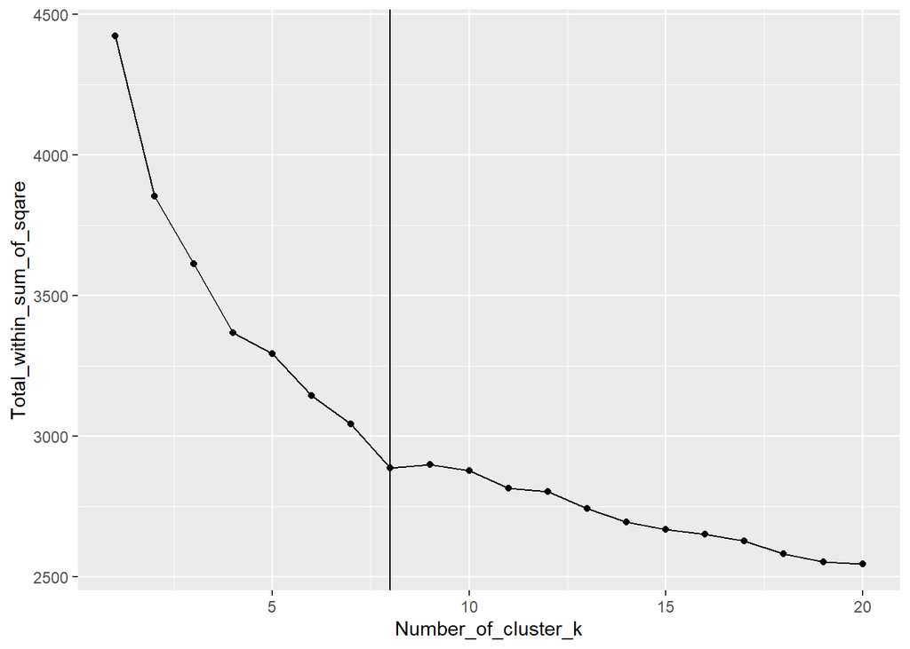

```r
# visualiztion choose optim clus : 7
ggplot(data = p_df, mapping = aes(x = Number_of_cluster_k, y = Total_within_sum_of_sqare))+
  geom_line() + geom_point()+geom_vline(xintercept = 8)
```

### 2. 執行7群的分群結果，並檢視其滿意度之分布

```r
c1 = kproto(x = dummies1,k=7 ,iter.max = 100, nstart = 1)
```

```
## # NAs in variables:
##                        GenderFemale      Customer.Typedisloyal Customer
##                                   0                                   0
##                                 Age       Type.of.TravelBusiness travel
##                                   0                                   0
##                       ClassBusiness                            ClassEco
##                                   0                                   0
##                     Flight.Distance               Inflight.wifi.service
##                                   0                                   0
##   Departure.Arrival.time.convenient              Ease.of.Online.booking
##                                   0                                   0
##                       Gate.location                      Food.and.drink
##                                   0                                   0
##                     Online.boarding                        Seat.comfort
##                                   0                                   0
##              Inflight.entertainment                    On.board.service
##                                   0                                   0
##                    Leg.room.service                    Baggage.handling
##                                   0                                   0
##                    Inflight.service                         Cleanliness
##                                   0                                   0
##          Departure.Delay.in.Minutes            Arrival.Delay.in.Minutes
##                                   0                                   0
## satisfactionneutral or dissatisfied               satisfactionsatisfied
##                                   0                                   0
## 0 observation(s) with NAs.
##
## Estimated lambda: 0.0299459
```

```r
clus_res = c()
for(i in 1:length(c1$cluster)){
  clus_res = append(clus_res,c1$cluster[[i]])
}
# append res to original data frame
data1$clus_res = clus_res %>% as.factor()

# check each clusters satisfation rate
table(c1$cluster, data1$satisfaction)
```

```
##
##     neutral or dissatisfied satisfied
##   1                     249       932
##   2                    1528       135
##   3                    1529       141
##   4                     296      1426
##   5                     314       849
##   6                    1606       141
##   7                     167       687
```

```r
# satisfatory 1~5 to fact
for(i in c(7:20)){
  data1[,i] = as.factor(data1[,i])
}
```

## 視覺畫呈現分群結果

### 1. 自訂兩種繪圖函數

```r
# two differnet ways to define a function with differnt type of for loop input(string v.s symble)
library(tidyverse)
# x_var for numeric
dnes_plot_xvar_gvar <- function(df, x_var, group_var) {
  df %>%
    ggplot(aes(x = {{x_var}},
               color = {{group_var}},
               fill  = {{group_var}},
               group = {{group_var}})) +
    geom_histogram(aes(y = ..density..),
                   alpha = 0.4, position = "identity") +
    geom_density(size = 1, fill = NA)
}

# x_var for category
dis_plot_xvar_gvar = function (data, column1, column2) {
  ggplot(data, aes_string(x = column1, fill = column2)) +
    geom_bar(position = position_dodge())+
    guides(fill=guide_legend(title=sprintf('%s', column2)))+
    xlab('clus_res')
}
```

### 2. 檢視不同滿意度在不同群組中之分布(以食物滿意度、網路滿意度、性別為例)

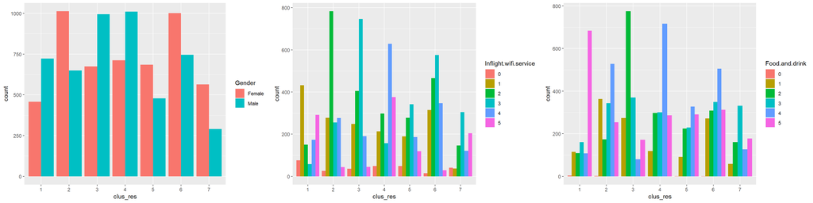

```r
gvar_c = vector(mode="list", length=19)
li = which(sapply(1:(length(data1)-1), function(x)class(data1[,x])=='factor'))
names(gvar_c) = sapply(li, function(x)names(data1)[x])
for (i in names(gvar_c)) {
  gvar_c[[i]] <- local({
    dis_plot_xvar_gvar(column2 = i, column1 = 'clus_res',data = data1)
  })
}
a = gvar_c$Gender
b = gvar_c$Inflight.wifi.service
c = gvar_c$Food.and.drink
library(ggpubr)
ggarrange(a,b,c, ncol = 3, nrow = 1, label = c('圖一', '圖二', '圖三'), size = 20)
```

### 3. 檢視不同滿意度在同群組中之分布

#### 結果描述:

圖一: 性別之分布在此群組中各個年齡層之差異

圖二: 在此群組中年輕人普遍不滿意網路服務，但中年客群在此群組中相當滿意

圖三: 在此群組中的年輕人對時間便利度相當不滿

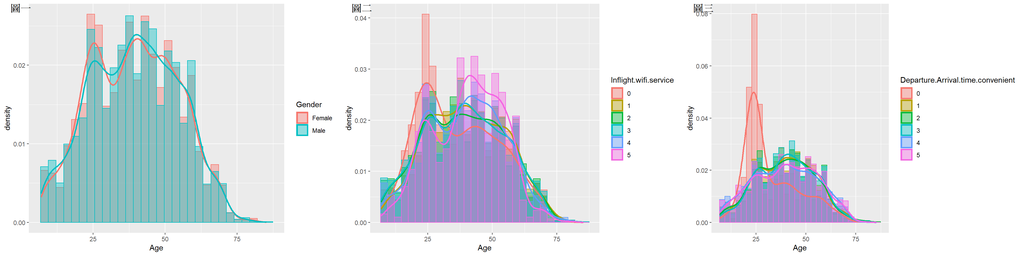

```r
# list for group var to store result
li = which(sapply(1:(length(data1)-1), function(x)class(data1[,x])=='factor'))
gvar_d = vector(mode="list", length=19)
names(gvar_d) = sapply(li, function(x)names(data1)[x])


library(rlang)

# age with diff catego####
for (i in names(gvar_d)) {
  gvar_d[[i]] <- local({
    eval(substitute(dnes_plot_xvar_gvar(data1, x_var = Age , group_var = x),list (x = ensym(i))))
  })

}

a = gvar_d$Gender
b = gvar_d$Inflight.wifi.service
c = gvar_d$Departure.Arrival.time.convenient
ggarrange(a,b,c, ncol = 3, nrow = 1, labels = c('圖一','圖二','圖三'))
```

###4. 檢視不同族群客戶的消費者行為與偏好

#### 結果描述:

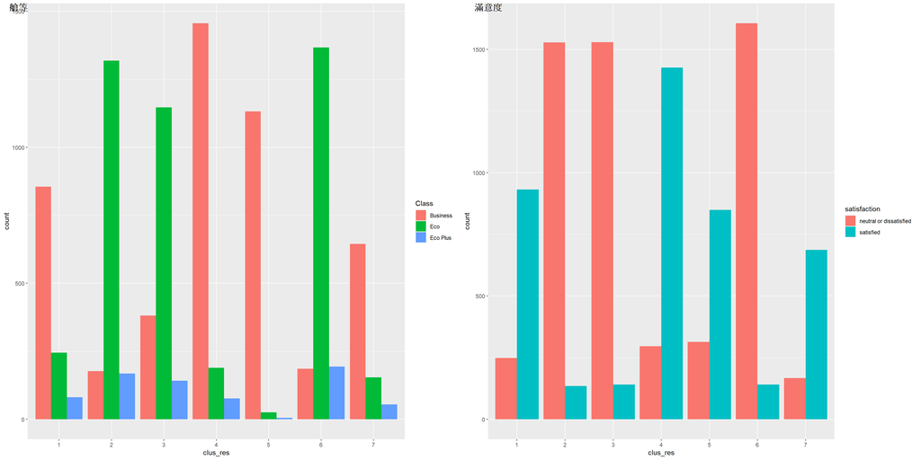

```r
e = gvar_c$Class
f = gvar_c$satisfaction
ggpubr::ggarrange(e, f, labels = c("艙等", "滿意度"), ncol = 2, nrow = 1)
```